# Rethinking_week05_2019-05-03

## Problems: 4M4, 4M5, 4M6, 4H1, 4H2

I think I’d better start with 4M1

### 4M1

For the model definition below, simulate observed heights from the prior (not the posterior).

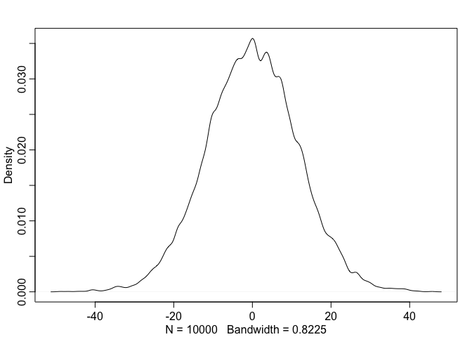

```r
sample_mu <- rnorm(1e4, 0,10 )
sample_sigma <- runif(1e4, 0, 10)

prior_y <- rnorm(1e4, sample_mu, sample_sigma)

dens(prior_y)
```

### 4M2

Make the above a quap function. What to do about data?

```r
#m4.m2 <- quap(
#  alist(
#    y ~ dnorm(mu, sigma),
#   mu ~ dnorm(0, 10),
#    sigma ~ dunif(0, 10)
#  )
#)

# can't actually run without data
```

### 4M3

Translate quap below into mathematical definitions

```r
flist <- alist(
    y ~ dnorm( mu , sigma ),
    mu <- a + b*x,
    a ~ dnorm( 0 , 50 ),
    b ~ dunif( 0 , 10 ),
    sigma ~ dunif( 0 , 50 )
)
```

$$y_i \sim Normal (\mu_i, \sigma) \ mu_i = \alpha + \beta x_i \ \alpha \sim Normal(0, 50) \ \beta \sim Uniform(0, 10) \ \sigma \sim Uniform(0, 50)$$
y ~ normal(mu, sigma) mu = a + beta * x a ~ normal(0, 50) b ~ uniform(0, 10) sigma ~ uniform(0, 50)

### 4M4

A sample of students is measured for height each year for 3 years. After the third year, you want to fit a linear regression predicting height using year as a predictor. Write down the mathematical model definition for this regression, using any variable names and priors you choose. Be prepared to defend your choice of priors.

height ~ Normal(mu, sigma) mu ~ a + beta*year a ~ Normal(150, 20)*  
I’m assuming that students are about 12 years old; internet search shows mean height in US about 150 cm. SD of 20 seems pretty generous *beta ~ Log-Normal(0, 1)*  
I’m assuming there is no shrinkage over time, and that most students don’t grow much over three years *sigma ~ dunif(0, 50)* This seems pretty broad to me; maybe should be more restricted?*

### 4M5

Now suppose I tell you that the average height in the first year was 120 cm and that every student got taller each year. Does this information lead you to change your choice of priors? How?

Yes, now I would change my a prior to be: a ~ Normal(120, 20)  
And maybe I’d change my beta as well, since beta should always be > 0 beta ~ Log-Normal(0.1, 1)

How different is that prior?

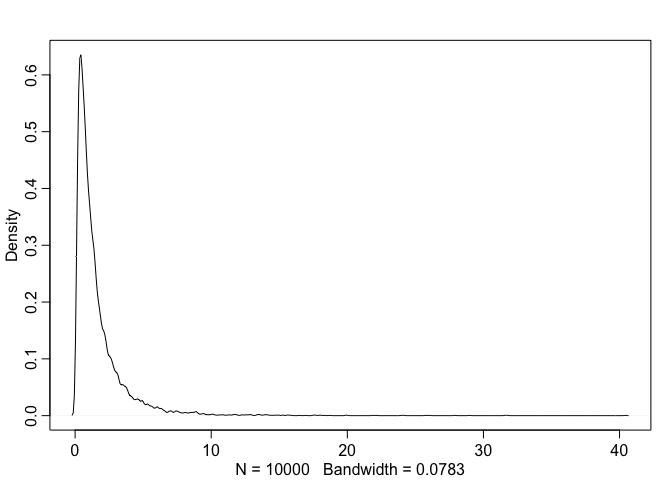

```r
dens(rlnorm( 1e4 , 0 , 1 ))
```

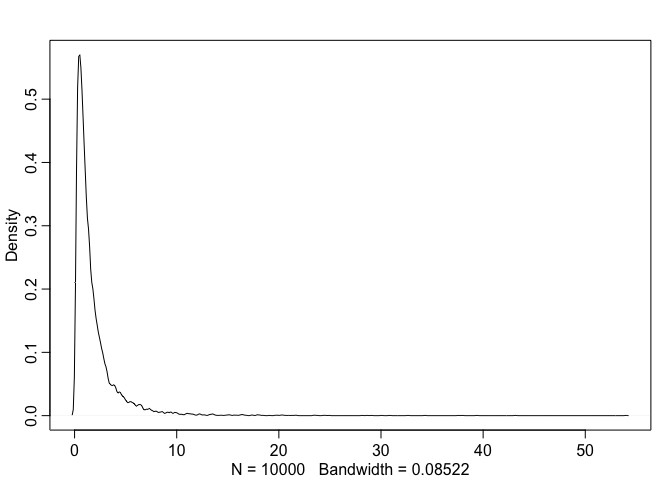

```r
dens(rlnorm( 1e4 , 0.1 , 1 ))
```

Subtle difference by eye.

### 4M6

Now suppose I tell you that the variance among heights for students of the same age is never more than 64cm. How does this lead you to revise your priors?

I’d want to limit my sigma value so absolute max is 64 So now I’d have:

height ~ Normal(mu, sigma) mu ~ a + beta*year a ~ Normal(120, 20)*  
mean value provided *beta ~ Log-Normal(0.1, 1)*  
I’m assuming there is no shrinkage over time, and that all students grow at least some *sigma ~ dunif(0, 64)* using suggested max variance*

### 4H1

The weights listed below were recorded in the !Kung census, but heights were not recorded for these individuals. Provide predicted heights and 89% intervals (either HPDI or PI) for each of these individuals.

I think that I need to regenerate models from the chapter, and then retrieve mu and HPDI for each of the 5 given weights. Given these weights, I will stick to the over 18 subset of the data

```r
library(rethinking)
data(Howell1)
d <- Howell1
d.4h1 <- d[ d$age >= 18 , ]
precis(d.4h1)
```

```
##             mean         sd     5.5%     94.5%       histogram
## height 154.59709  7.7423321 142.8750 167.00500       ▁▃▇▇▅▇▂▁▁
## weight  44.99049  6.4567081  35.1375  55.76588         ▁▅▇▇▃▂▁
## age     41.13849 15.9678551  20.0000  70.00000 ▂▅▇▅▃▇▃▃▂▂▂▁▁▁▁
## male     0.46875  0.4997328   0.0000   1.00000      ▇▁▁▁▁▁▁▁▁▇
```

In my case, I’ll use the population mean as the prior; why not? mean height is 155;

my linear model will be mu = a + beta*weight. I’ll use quap (see p 98)

```r
# avg weight defined
xbar <- mean(d.4h1$weight)  # about 45 kg

m.4h1 <- quap(
  alist(
    height ~ dnorm(mu, sigma),
    mu <- a + b*(weight - xbar),
    a ~ dnorm(155, 20),
    b ~ dlnorm(0, 1),
    sigma ~ dunif(0, 50)
  ),
  data = d.4h1
)

precis(m.4h1)
```

```
##              mean         sd        5.5%       94.5%
## a     154.5971651 0.27030746 154.1651615 155.0291686
## b       0.9032806 0.04192363   0.8362785   0.9702826
## sigma   5.0718808 0.19115474   4.7663786   5.3773830
```

Now I think that I want to extract samples from the posterior.

```r
post.4h1 <- extract.samples( m.4h1 , n=1e4 )
```

And now I want to determine what intervals are for given weights

First one is 46.95; test it

```r
mu.1 <- post.4h1$a + post.4h1$b * ( 46.95 - xbar )
length(mu.1) # 1e4, vector I believe
```

```
## [1] 10000
```

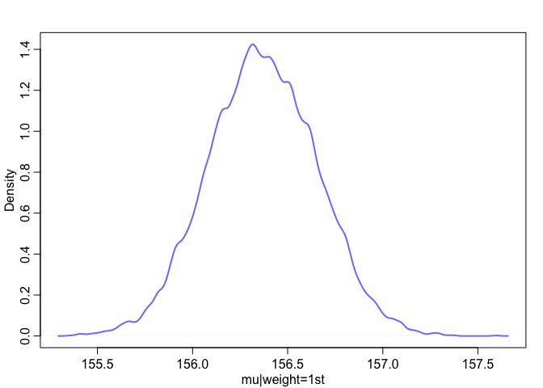

```r
dens( mu.1 , col=rangi2 , lwd=2 , xlab="mu|weight=1st" )
```

and

```r
chainmode( mu.1 , adj=0.01 ) # 156.35 is the 'most expected' height
```

```
## [1] 156.3159
```

```r
HPDI( mu.1 , prob=0.89 )
```

```
##    |0.89    0.89|
## 155.9102 156.8143
```

Can I do this systematically for all 5 values? I am sure there is clever loop way to do this, but how to set it up?

Or why not try sapply instead???

```r
cases <- c(46.95, 43.72, 64.78, 32.59, 54.63)

samples.all <- sapply( cases , function(c) post.4h1$a + post.4h1$b * ( c - xbar ) )  # I think that looks right

# now determine 'most expected' from each column;

apply(samples.all, 2, function(x) chainmode(x, adj=0.01 ))
```

```
## [1] 156.3159 153.5216 172.6191 143.2463 163.3658
```

```r
# and now determine HPDI

apply(samples.all, 2, function(x) HPDI(x, prob=0.89 ))
```

```
##           [,1]     [,2]     [,3]     [,4]     [,5]
## |0.89 155.9102 153.0178 171.0351 142.4406 162.5145
## 0.89| 156.8143 153.9007 173.8116 144.2943 164.0558
```

Not pretty, but seemed to work

### 4H2

Select out all the rows in the Howell1 data with ages below 18 years of age. If you do it right, you should end up with a new data frame with 192 rows in it.

```r
data(Howell1)
d <- Howell1
d.4h2 <- d[ d$age < 18 , ]
precis(d.4h2) # mean height is 108; SD is 26
```

```
##               mean         sd      5.5%     94.5%   histogram
## height 108.3188531 25.7451390 66.360675 147.63432 ▁▃▂▅▅▃▇▇▃▅▁
## weight  18.4141931  8.9393135  7.243439  35.16429   ▁▅▇▅▅▃▁▁▁
## age      7.7218750  5.3662354  0.303000  16.00000   ▇▃▅▃▂▃▂▃▂
## male     0.4791667  0.5008718  0.000000   1.00000  ▇▁▁▁▁▁▁▁▁▇
```

1. Fit a linear regression to these data, using quap. Present and interpret the estimates. For every 10 units of increase in weight, how much taller does the model predict a child gets?

```r
# avg weight defined
xbar.h2 <- mean(d.4h2$weight)  # about 18.4 kg

m.4h2 <- quap(
  alist(
    height ~ dnorm(mu, sigma),
    mu <- a + b*(weight - xbar.h2),
    a ~ dnorm(100, 40),   #kind of wide prior
    b ~ dlnorm(0, 1),
    sigma ~ dunif(0, 50)
  ),
  data = d.4h2
)

precis(m.4h2)
```

```
##             mean         sd       5.5%      94.5%
## a     108.316915 0.60882916 107.343888 109.289941
## b       2.716657 0.06831537   2.607476   2.825838
## sigma   8.437161 0.43056300   7.749039   9.125284
```

The population mean is estimated as 108.32 (same as in actual data), with 89% interval between 107.4 and 109.3 beta is estimated at 2.72. So for every 10 units more weight, we’d expect child to be 10*2.72 = 27.2 units taller.

2. Plot the raw data, with height on the vertical axis and weight on the horizontal axis. Superimpose the MAP regression line and 89% HPDI for the mean. Also superimpose the 89% HPDI for predicted heights.

see p 109

```r
# first, extract samples from posterior
post.4h2 <- extract.samples(m.4h2)
mu.link <- function(weight) post.4h2$a + post.4h2$b*( weight - xbar.h2 )

# define range of weights for plotting
weight.seq <- seq( from=0 , to=50 , by=1 )

mu.4h2 <- sapply( weight.seq , mu.link )
mu.mean.4h2 <- apply( mu.4h2 , 2 , mean )
mu.HPDI.4h2 <- apply( mu.4h2 , 2 , HPDI , prob=0.89 )


# and obtain simulated/predicted heights
sim.height.4h2 <- sim( m.4h2 , data=list(weight=weight.seq) )
str(sim.height.4h2)
```

```
##  num [1:1000, 1:51] 49 54.8 56.4 46.4 42.9 ...
```

```r
# summarize simulated heights
height.HPDI.4h2 <- apply( sim.height.4h2 , 2 , HPDI , prob=0.89 )
```

OK, do I have all I need now?

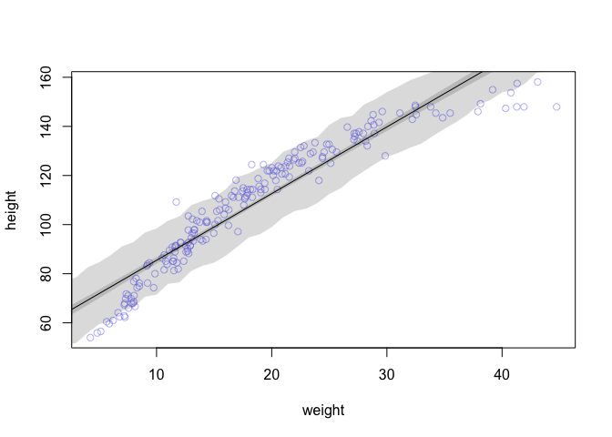

```r
# plot raw data
plot( height ~ weight , d.4h2 , col=col.alpha(rangi2,0.5) )

# draw MAP line
lines( weight.seq , mu.mean.4h2 )

# draw HPDI region for line
shade( mu.HPDI.4h2 , weight.seq )

# draw HPDI region for simulated heights
shade( height.HPDI.4h2 , weight.seq )
```

(c) What aspects of the model fit concern you? Describe the kinds of assumptions you would change, if any, to improve the model. You don’t have to write any new code. Just explain what the model appears to be doing a bad job of, and what you hypothesize would be a better model.

The data don’t fit the line well; the relationship between weight and height clearly isn’t linear over the entire range. (Seems at low weights, rapid increases in height but not weight; at high weights, the opposite. ) So the model is doing a very poor job of predicting relationships at both the high and the low ends of the data range.

For a better model, I might try using B-spline, or perhaps quadratic regression.